# Word Frequencies

Introduction to Text as Data

Amber Boydstun & Cory Struthers

April 27-29, 2023

### Introduction

The bag of words model is the prevailing approach to text representation. The fundamental concept is straightforward: we will represent each document by counting how many times each word appears in it. Think of taking all the words in a given document (or set of documents) of interest, and shaking them all up in a bag so they are no longer in order.

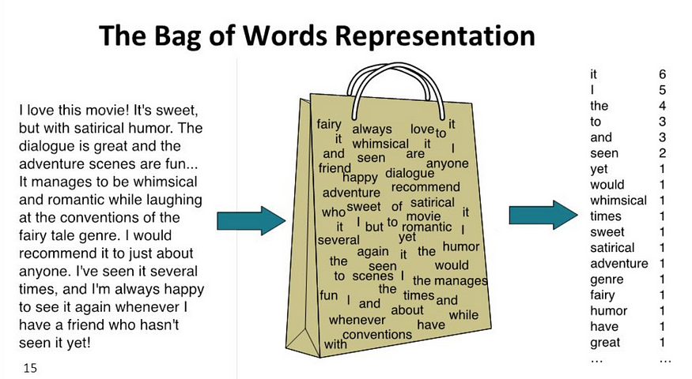

In this module, we’ll need the following packages:

```r
# Load packages
require(tidyverse)
require(quanteda)
require(quanteda.textstats)
require(quanteda.textplots)
library(stringr)
library(ggplot2)
library(ggpubr)

# Set working directory
setwd("/Users/cs86487/Dropbox/text-as-data-JUST-CORY-AND-AMBER/modules/data/")
getwd() # view working directory
```

Let’s take a simple toy example to explain how we can apply the bag of words model to the real life case. Here are three fictitious reviews about a particular tech product. Let’s say we’d like to know how people think whether this product is worth buying by analyzing the words that are used most frequently by consumers.

```r
cus_rev = c(review1 = "This product is useful and fancy.",
             review2 = "This product is useful but not trending.",
             review3 = "This product is awesome and is fancy.")
cus_rev
```

```
##                                    review1
##        "This product is useful and fancy."
##                                    review2
## "This product is useful but not trending."
##                                    review3
##    "This product is awesome and is fancy."
```

These three toy reviews are easy enough for us to comprehend, but if we had thousands or millions of reviews, it would surely be useful to be able to take an automated count of how many times each word is used overall, as well as whether these word frequencies vary by any meta data variables we might have, such as geographic location or age of the reviewer.

### Create document frequency matrix (DFM)

Before applying the bag of words model to our sample of reviews on this hypothetical tech product, there are a multitude of small steps that have to be made to clean the text data. Many of these steps were illustrated through tokenization in the pre-processing module and are performed on example corpus below.

```r
# Create corpus
cus_rev_corp = corpus(cus_rev)
cus_rev_corp
```

```
## Corpus consisting of 3 documents.
## review1 :
## "This product is useful and fancy."
##
## review2 :
## "This product is useful but not trending."
##
## review3 :
## "This product is awesome and is fancy."
```

```r
# Tokenize
cus_rev_toks = tokens(cus_rev_corp,
                        remove_punct = TRUE)
print(cus_rev_toks)
```

```
## Tokens consisting of 3 documents.
## review1 :
## [1] "This"    "product" "is"      "useful"  "and"     "fancy"
##
## review2 :
## [1] "This"     "product"  "is"       "useful"   "but"      "not"      "trending"
##
## review3 :
## [1] "This"    "product" "is"      "awesome" "and"     "is"      "fancy"
```

After tokenization, we can move to the next step: use `dfm()` to convert the corpus of documents to a document-feature matrix (DFM), which is simply a massive table where every row is a document in the corpus (here we’re still treating reviews as separate entities, even though eventually we’ll jumble them all together to count words), and every column is a `token’ (either a word or phrase). The values in the cells show the number of times a token appears in the document.

```r
# Create a document-feature matrix
cus_rev_dfm = dfm(cus_rev_toks)
cus_rev_dfm
```

```
## Document-feature matrix of: 3 documents, 10 features (36.67% sparse) and 0 docvars.
##          features
## docs      this product is useful and fancy but not trending awesome
##   review1    1       1  1      1   1     1   0   0        0       0
##   review2    1       1  1      1   0     0   1   1        1       0
##   review3    1       1  2      0   1     1   0   0        0       1
```

```r
# Number of features (i.e., unique words or phrases)
nfeat(cus_rev_dfm)
```

```
## [1] 10
```

```r
# Examine sums across documents
colSums(cus_rev_dfm)
```

```
##     this  product       is   useful      and    fancy      but      not
##        3        3        4        2        2        2        1        1
## trending  awesome
##        1        1
```

### Calculate basic word frequencies

`topfeatures()` in `quanteda` will provide the word frequencies for all the reviews in descending order.

```r
# Get top features
topfeatures(cus_rev_dfm, decreasing = TRUE)
```

```
##       is     this  product   useful      and    fancy      but      not
##        4        3        3        2        2        2        1        1
## trending  awesome
##        1        1
```

The `textstat_frequency()` function in `quanteda.textstats package` is also a useful function for calculating term frequencies in a corpus of text data. In addition to providing feature counts, it ranks features and provides each feature’s document frequency.

```r
# Get frequency and ranking
textstat_frequency(cus_rev_dfm)
```

|  | feature | frequency | rank | docfreq | group |
| --- | --- | --- | --- | --- | --- |
| 1 | is | 4 | 1 | 3 | all |
| 2 | this | 3 | 2 | 3 | all |
| 3 | product | 3 | 2 | 3 | all |
| 4 | useful | 2 | 4 | 2 | all |
| 5 | and | 2 | 4 | 2 | all |
| 6 | fancy | 2 | 4 | 2 | all |
| 7 | but | 1 | 7 | 1 | all |
| 8 | not | 1 | 7 | 1 | all |
| 9 | trending | 1 | 7 | 1 | all |
| 10 | awesome | 1 | 7 | 1 | all |

Because we have not removed stopwords from the tokens list, “is” and “this” are among the most frequent words appearing in the tech product reviews. Oftentimes, the top features in a corpus represent no meaningful latent concept. However, others do. **Useful** and **fancy** are two words that are used somewhat frequently to describe the product. The frequency of these words suggest that, overall, consumers have positive impression on this product.

Now we’ll apply the bag of words model to another example with more text data.

During the 2016 presidential election campaigns, people noticed a peculiar trend. When then-presidential candidate Donald Trump posted positive tweets to Twitter, they came from an iPhone. When he posted negative tweets to Twitter, they came from an Android. Some speculated that Trump’s Android and iPhone tweets were therefore written by different people.

David Robinson, the author of the book “R for text mining,” collected Trump’s tweets from 12/14/2015-08/08/2016 and found that Trump’s Android tweets were angrier and more negative than iPhone tweets. Here, we are going to use the [Twitter data collected from David Robinson](http://varianceexplained.org/r/trump-tweets/) to examine which words were most common among Android-posted and iPhone-posted tweets.

```r
# Import data
load(url("http://varianceexplained.org/files/trump_tweets_df.rda"))
View(trump_tweets_df)

# Create new variable with phone type
tweets_df = trump_tweets_df %>%
    mutate(doc_id  = row_number()) %>%
    select(doc_id, statusSource, text, created) %>%
    mutate(source = str_replace(statusSource, ".*Twitter for (.*?)<.*", "\\1")) %>%
    filter(source %in% c("iPhone", "Android")) %>%
    filter(!str_detect(text, '^"')) %>% # remove " at the start of each line
    mutate(text = str_replace_all(text, "https://t.co/[A-Za-z\\d]+|&amp;", "")) %>%
    select(doc_id, source, text, created)

tweets_df$doc_id = as.character(tweets_df$doc_id)

head(tweets_df)
```

| doc_id | source | text | created |
| --- | --- | --- | --- |
| 1 | Android | My economic policy speech will be carried live at 12:15 P.M. Enjoy! | 2016-08-08 15:20:44 |
| 2 | iPhone | Join me in Fayetteville, North Carolina tomorrow evening at 6pm. Tickets now available at: | 2016-08-08 13:28:20 |
| 3 | iPhone | #ICYMI: "Will Media Apologize to Trump?" | 2016-08-08 00:05:54 |
| 4 | Android | Michael Morell, the lightweight former Acting Director of C.I.A., and a man who has made serious bad calls, is a total Clinton flunky! | 2016-08-07 23:09:08 |
| 5 | Android | The media is going crazy. They totally distort so many things on purpose. Crimea, nuclear, "the baby" and so much more. Very dishonest! | 2016-08-07 21:31:46 |
| 6 | Android | I see where Mayor Stephanie Rawlings-Blake of Baltimore is pushing Crooked hard. Look at the job she has done in Baltimore. She is a joke! | 2016-08-07 13:49:29 |

In this example, the unit of analysis is a tweet. We are interested in differences in term frequencies between two groups: tweets by iPhone and tweets by Android. As we’ve done before, we convert the raw text to corpus, then tokens, then dfm objects.

```r
# Convert text to corpus, view docvars
tweet_corp = corpus(tweets_df, text_field="text")
head(docvars(tweet_corp),10)
```

|  | source | created |
| --- | --- | --- |
| 1 | Android | 2016-08-08 15:20:44 |
| 2 | iPhone | 2016-08-08 13:28:20 |
| 3 | iPhone | 2016-08-08 00:05:54 |
| 4 | Android | 2016-08-07 23:09:08 |
| 5 | Android | 2016-08-07 21:31:46 |
| 6 | Android | 2016-08-07 13:49:29 |
| 7 | iPhone | 2016-08-07 02:19:37 |
| 8 | iPhone | 2016-08-07 02:03:39 |
| 9 | Android | 2016-08-07 01:53:45 |
| 10 | iPhone | 2016-08-06 20:04:08 |

```r
# Save corpus object for next module
saveRDS(tweet_corp, "trump_tweet_corp.rds")

# Transform to tokens
tweet_toks = tweet_corp  %>%
    tokens(remove_punct = TRUE,
           remove_numbers = TRUE,
           remove_symbols = TRUE,
           remove_url = TRUE) %>%
    tokens_tolower() %>%
    tokens_remove(stopwords("english"))
head(tweet_toks)
```

```
## Tokens consisting of 6 documents and 2 docvars.
## 1 :
## [1] "economic" "policy"   "speech"   "carried"  "live"     "enjoy"
##
## 2 :
##  [1] "join"         "fayetteville" "north"        "carolina"     "tomorrow"
##  [6] "evening"      "6pm"          "tickets"      "now"          "available"
##
## 3 :
## [1] "#icymi"    "media"     "apologize" "trump"
##
## 4 :
##  [1] "michael"     "morell"      "lightweight" "former"      "acting"
##  [6] "director"    "man"         "made"        "serious"     "bad"
## [11] "calls"       "total"
## [ ... and 2 more ]
##
## 5 :
##  [1] "media"   "going"   "crazy"   "totally" "distort" "many"    "things"
##  [8] "purpose" "crimea"  "nuclear" "baby"    "much"
## [ ... and 1 more ]
##
## 6 :
##  [1] "see"            "mayor"          "stephanie"      "rawlings-blake"
##  [5] "baltimore"      "pushing"        "crooked"        "hard"
##  [9] "look"           "job"            "done"           "baltimore"
## [ ... and 1 more ]
```

Some dfms are very large, involving hundreds of thousands of documents and millions of features. Features within those documents may be used rarely across the whole corpus, or used many times but only in a single document. Many text analysis methods do not infer meaning from terms mentioned very few times, and retaining all terms in really large corpora increases computational complexity (i.e., the time it takes to complete the task).

Thus, the researcher has the option of “trimming” the dfm to exclude infrequent terms using `dfm_trim`. When used appropriately, trimming can decrease processing time without losing quality. In fact, reducing *sparseness* or *sparsity* in the matrix (i.e., the proportion of cells that have zero counts) is particularly important for more complex computational tasks in order to avoid over-fitting and using memory.

- `min_termfreq` removes any features that occur less than *n* times in the corpus (no matter the distribution across documents).
- `min_docfreq` removes any features that occur in less than *n* times across *documents*.
- `docfreq_type` (an option) specifies a count or proportion.

Depending on the question, ubiquitous terms can also have little meaning. `quanteda` offers a `max` equivalent of the above but we don’t suggest using it as often, in part because common terms may not be distributed evenly across groups we care about.

```r
# min_termfreq = 15
tweet_dfm = dfm(tweet_toks)
print(tweet_dfm)
```

```
## Document-feature matrix of: 1,175 documents, 2,973 features (99.68% sparse) and 2 docvars.
##     features
## docs economic policy speech carried live enjoy join fayetteville north carolina
##    1        1      1      1       1    1     1    0            0     0        0
##    2        0      0      0       0    0     0    1            1     1        1
##    3        0      0      0       0    0     0    0            0     0        0
##    4        0      0      0       0    0     0    0            0     0        0
##    5        0      0      0       0    0     0    0            0     0        0
##    6        0      0      0       0    0     0    0            0     0        0
## [ reached max_ndoc ... 1,169 more documents, reached max_nfeat ... 2,963 more features ]
```

```r
tweet_dfm_feat_trim = tweet_dfm %>%
  dfm_trim(min_termfreq = 5)
print(tweet_dfm_feat_trim)
```

```
## Document-feature matrix of: 1,175 documents, 526 features (98.81% sparse) and 2 docvars.
##     features
## docs speech enjoy join north carolina tomorrow evening tickets now media
##    1      1     1    0     0        0        0       0       0   0     0
##    2      0     0    1     1        1        1       1       1   1     0
##    3      0     0    0     0        0        0       0       0   0     1
##    4      0     0    0     0        0        0       0       0   0     0
##    5      0     0    0     0        0        0       0       0   0     1
##    6      0     0    0     0        0        0       0       0   0     0
## [ reached max_ndoc ... 1,169 more documents, reached max_nfeat ... 516 more features ]
```

```r
# min_docfreq = 3, features that occur in more than 90% of the documents are removed
tweet_dfm_doc_trim = tweet_dfm %>%
  dfm_trim(min_docfreq = 10, docfreq_type = "count") # count, prop, rank, quartile
print(tweet_dfm_doc_trim)
```

```
## Document-feature matrix of: 1,175 documents, 222 features (97.92% sparse) and 2 docvars.
##     features
## docs speech enjoy join carolina tomorrow tickets now media trump lightweight
##    1      1     1    0        0        0       0   0     0     0           0
##    2      0     0    1        1        1       1   1     0     0           0
##    3      0     0    0        0        0       0   0     1     1           0
##    4      0     0    0        0        0       0   0     0     0           1
##    5      0     0    0        0        0       0   0     1     0           0
##    6      0     0    0        0        0       0   0     0     0           0
## [ reached max_ndoc ... 1,169 more documents, reached max_nfeat ... 212 more features ]
```

```r
# used together
tweet_dfm_trim = tweet_dfm %>%
  dfm_trim(min_termfreq = 10, min_docfreq = 10, docfreq_type = "count")
print(tweet_dfm_trim)
```

```
## Document-feature matrix of: 1,175 documents, 222 features (97.92% sparse) and 2 docvars.
##     features
## docs speech enjoy join carolina tomorrow tickets now media trump lightweight
##    1      1     1    0        0        0       0   0     0     0           0
##    2      0     0    1        1        1       1   1     0     0           0
##    3      0     0    0        0        0       0   0     1     1           0
##    4      0     0    0        0        0       0   0     0     0           1
##    5      0     0    0        0        0       0   0     1     0           0
##    6      0     0    0        0        0       0   0     0     0           0
## [ reached max_ndoc ... 1,169 more documents, reached max_nfeat ... 212 more features ]
```

### Visualizing word frequencies

After trimming (as appropriate), we can pipe the `textplot_wordcloud` function through `dfm`, grouping by source.

```r
# Pipe grouping through trimming step
tweet_dfm_trim_source = dfm(tweet_toks) %>%
                       dfm_trim(min_termfreq = 10, min_docfreq = 10, docfreq_type = "count") %>%
                       dfm_group(groups = source)
print(tweet_dfm_trim_source)
```

```
## Document-feature matrix of: 2 documents, 222 features (3.38% sparse) and 1 docvar.
##          features
## docs      speech enjoy join carolina tomorrow tickets now media trump
##   Android     17    19    0       11        1       1  33    30    30
##   iPhone       9    16   42       13       22      14  17     7    24
##          features
## docs      lightweight
##   Android           5
##   iPhone            8
## [ reached max_nfeat ... 212 more features ]
```

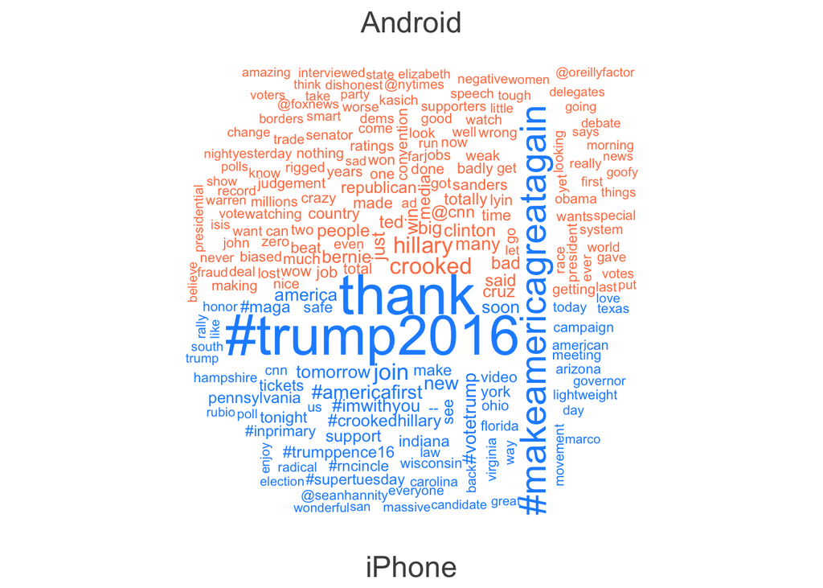

```r
set.seed(132) # set seed so figure can be reproduced
textplot_wordcloud(tweet_dfm_trim_source, comparison = TRUE, max_words = 200, color = c("coral","dodgerblue"), min_size=0.9)
```

Alternatively, we can pipe the `textstat_frequency` function through `dfm`, grouping by source.

```r
tweet_words_freq = dfm(tweet_dfm_trim) %>%
    textstat_frequency(groups = source) # grouping the term frequencies by source
head(tweet_words_freq)
```

|  | feature | frequency | rank | docfreq | group |
| --- | --- | --- | --- | --- | --- |
| 1 | hillary | 123 | 1 | 114 | Android |
| 2 | great | 102 | 2 | 94 | Android |
| 3 | crooked | 93 | 3 | 92 | Android |
| 4 | clinton | 66 | 4 | 65 | Android |
| 5 | people | 63 | 5 | 59 | Android |
| 6 | just | 57 | 6 | 57 | Android |

Let’s plot the top 15 more frequent words used in Trump’s tweets from Android and from iPhone.

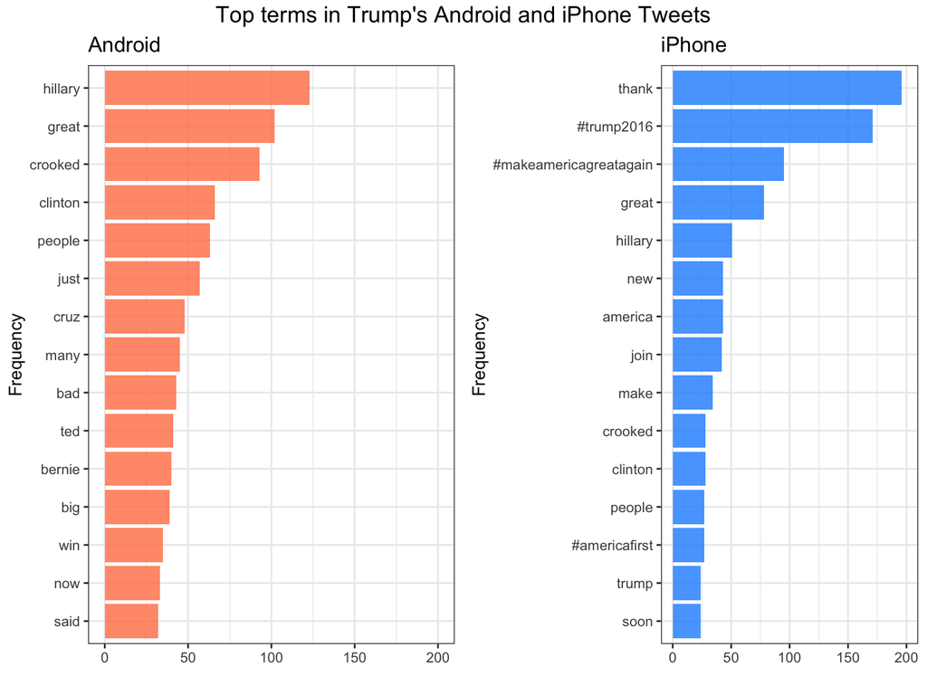

```r
# First create dfs with top 15 features
android15_df = tweet_words_freq %>%
    filter(group == "Android") %>%
    head(15)
iphone15_df = tweet_words_freq %>%
    filter(group == "iPhone") %>%
    head(15)

# Plot and arrange side by side
android15_plot = ggplot(data = android15_df, aes(x = reorder(feature, frequency), y = frequency)) +
    geom_col(stat = "identity", alpha = 0.8, fill = "coral",
             position = position_dodge(width = 0.8)) +
    scale_y_continuous(limits = c(0, 200)) +
    xlab("Frequency") + ylab("") +
    ggtitle("Android") +
    coord_flip() +
    theme_bw()

iphone15_plot = ggplot(data = iphone15_df, aes(x = reorder(feature, frequency), y = frequency)) +
    geom_col(stat = "identity", alpha = 0.8, fill = "dodgerblue",
             position = position_dodge(width = 0.8)) +
    scale_y_continuous(limits = c(0, 200)) +
    xlab("Frequency") + ylab("") +
    ggtitle("iPhone") +
    coord_flip() +
    theme_bw()

ggpubr::ggarrange(android15_plot, iphone15_plot) %>%
  annotate_figure(top = text_grob("Top terms in Trump's Android and iPhone Tweets",  size = 14))
```

By plotting the top 15 most frequent words used from Trump’s Android and iPhone, we can see that “hillary”, “crooked”, and “bad” is mentioned more often in Android tweets than iPhone tweets. We also observe features like “#trump2016” and “#makeamericagreatagain”, both of which have positive implications.

**Question 1 (BREAKOUT). Using the “immigration_news_1995-2017.csv” sample corpus, pre-process the corpus so it is ready for analysis using a bag of words model. List the top 15 most frequently occurring terms in these news articles. What do these words tell us about the documents in our corpus? Create a wordcloud using the top terms.**

### Understanding and applying TF-IDF

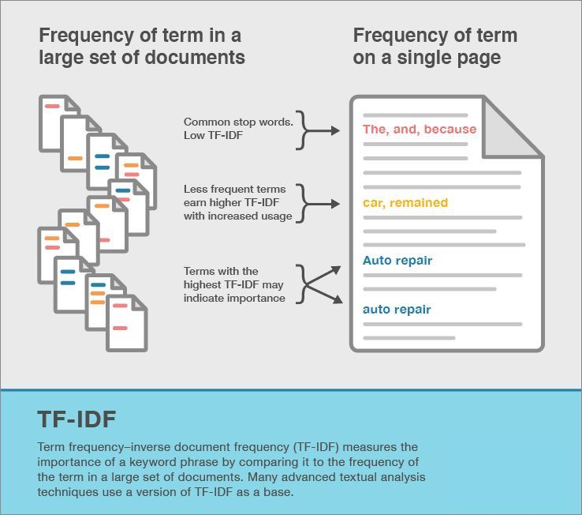

The example above used a bag-of-words approach to analyzing Trump’s tweets, with the objective of taking a simple count of how many times each term appeared.

Let’s see how things change if we use another bag-of-words approach with an alternative conceptualization of relative term importance or uniqueness: TF-IDF (Term Frequency-Inverse Document Frequency). The general intuition of TF-IDF is that term frequency should increase with the number of times it appears in a document after its frequency across all documents is accounted for. TF-IDF accounts for the fact that some terms appear frequently across all documents, which makes the term less meaningful conceptually. It is calculated as follows, where $W_{ij}$ represents the term count relative to all document terms, $N$ represents the number of total documents, and $n_j$ represents the number of documents containing the term:

$tf-idf = W_{ij}*log\frac{N}{n_j}$

Alternatively,

**(# of times a term appears in a document/# of terms in a document) X (log(# of documents/# of documents containing the term)**

`quanteda` uses the function `dfm_tfidf` to calculate TF-IDF. Let’s first apply it to the whole tweet corpus.

```r
tweet_dfm_tfidf = dfm(tweet_toks) %>%
  dfm_trim(min_termfreq = 10, min_docfreq = 10, docfreq_type = "count")  %>%
  dfm_tfidf()
print(tweet_dfm_tfidf)
```

```
## Document-feature matrix of: 1,175 documents, 222 features (97.92% sparse) and 2 docvars.
##     features
## docs   speech   enjoy     join carolina tomorrow  tickets      now    media
##    1 1.655065 1.52597 0        0         0       0        0        0
##    2 0        0       1.446789 1.689827  1.70831 1.893947 1.379842 0
##    3 0        0       0        0         0       0        0        1.501836
##    4 0        0       0        0         0       0        0        0
##    5 0        0       0        0         0       0        0        1.501836
##    6 0        0       0        0         0       0        0        0
##     features
## docs    trump lightweight
##    1 0           0
##    2 0           0
##    3 1.354035    0
##    4 0           1.956095
##    5 0           0
##    6 0           0
## [ reached max_ndoc ... 1,169 more documents, reached max_nfeat ... 212 more features ]
```

The terms are now weighted, according to their rareness relative to other documents.

Here’s where things get tricky. Recall that we want to compare Android and iPhone tweets, which means we need to group frequencies. With basic word frequency, we group the dfm into the two sources before applying `textstat_frequency` to get word counts. As illustrated in the calculation above, ith TF-IDF, word count is weighted by the *relative* appearance across documents.

But what is the number of documents when we group? When we don’t group?

Let’s first apply `dfm_tfidf` after we assign tweets to their source group.

```r
# Convert to grouped dfm, trim, and calculate tf-idf
tweet_dfm_tfidf_grouped = dfm(tweet_toks) %>%
  dfm_group(group=source) %>%
  dfm_trim(min_termfreq = 10, min_docfreq = 10, docfreq_type = "count")  %>% # removing docfreq because of groups %>%
  dfm_tfidf()
print(tweet_dfm_tfidf_grouped)
```

```
## Document-feature matrix of: 2 documents, 0 features (0.00% sparse) and 1 docvar.
```

**Question 2: Oops, what went wrong here?**

Trying again:

```r
# Convert to trimmed dfm, group, and calculate tf-idf
tweet_dfm_tfidf_grouped = dfm(tweet_toks) %>%
  dfm_trim(min_termfreq = 5, min_docfreq = 5, docfreq_type = "count")  %>%
  dfm_group(group=source) %>%
  dfm_tfidf()
print(tweet_dfm_tfidf_grouped)
```

```
## Document-feature matrix of: 2 documents, 516 features (6.59% sparse) and 1 docvar.
##          features
## docs      speech enjoy     join north carolina tomorrow evening tickets now
##   Android      0     0  0           0        0        0       0       0   0
##   iPhone       0     0 12.64326     0        0        0       0       0   0
##          features
## docs      media
##   Android     0
##   iPhone      0
## [ reached max_nfeat ... 506 more features ]
```

By grouping, we now have only two documents. Just as we did for word frequency, let’s observe and plot TF-IDF scores for Android and iPhone tweets. Note that `quanteda` requires the option `force=TRUE` to generate grouped frequencies. *Forcing* something should give us pause. `quanteda`’s authors are telling us to use the option with caution! We’ll see why momentarily.

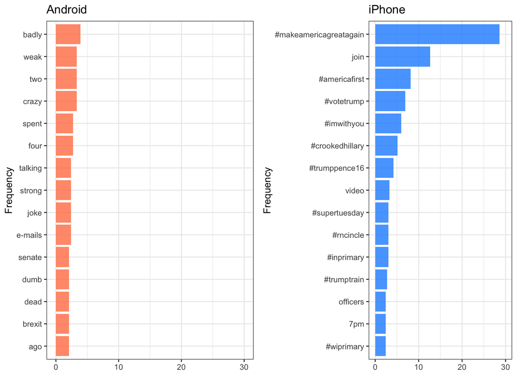

```r
# Generate frequency lists
tweet_tfidf_freq_grouped = dfm(tweet_dfm_tfidf_grouped) %>%
    textstat_frequency(groups = source, force=TRUE)

# Create dfs with top 15 features
android15_tfidf = tweet_tfidf_freq_grouped %>%
    filter(group == "Android") %>%
    arrange(desc(frequency)) %>%
    head(15)
iphone15_tfidf = tweet_tfidf_freq_grouped %>%
    filter(group == "iPhone") %>%
    arrange(desc(frequency)) %>%
    head(15)

# Plot and arrange side by side
android15_tfidf_plot = ggplot(data = android15_tfidf , aes(x = reorder(feature, frequency), y = frequency)) +
    geom_col(stat = "identity", alpha = 0.8, fill = "coral",
             position = position_dodge(width = 0.8)) +
    scale_y_continuous(limits = c(0, 30)) +
    xlab("Frequency") + ylab("") +
    ggtitle("Android") +
    coord_flip() +
    theme_bw()

iphone15_tfidf_plot = ggplot(data = iphone15_tfidf, aes(x = reorder(feature, frequency), y = frequency)) +
    geom_col(stat = "identity", alpha = 0.8, fill = "dodgerblue",
             position = position_dodge(width = 0.8)) +
    scale_y_continuous(limits = c(0, 30)) +
    xlab("Frequency") + ylab("") +
    ggtitle("iPhone") +
    coord_flip() +
    theme_bw()

ggpubr::ggarrange(android15_tfidf_plot, iphone15_tfidf_plot)
```

First observe how many terms have zeros are in the `tweet_tfidf_df_freq` dataframe compared to `tweet_words_freq`.

```r
head(count(tweet_tfidf_freq_grouped, frequency),5)
```

|  | frequency | n |
| --- | --- | --- |
| 1 | 0.00000 | 896 |
| 2 | 1.50515 | 23 |
| 3 | 1.80618 | 14 |
| 4 | 2.10721 | 5 |
| 5 | 2.40824 | 8 |

```r
head(count(tweet_words_freq, frequency),5)
```

|  | frequency | n |
| --- | --- | --- |
| 1 | 1 | 13 |
| 2 | 2 | 13 |
| 3 | 3 | 31 |
| 4 | 4 | 33 |
| 5 | 5 | 32 |

**(# of times a term appears in a document/# of terms in a document) X (log(# of documents/# of documents containing the term)**

```r
# Android
print(android15_df)
```

```
##    feature frequency rank docfreq   group
## 1  hillary       123    1     114 Android
## 2    great       102    2      94 Android
## 3  crooked        93    3      92 Android
## 4  clinton        66    4      65 Android
## 5   people        63    5      59 Android
## 6     just        57    6      57 Android
## 7     cruz        48    7      44 Android
## 8     many        45    8      43 Android
## 9      bad        43    9      40 Android
## 10     ted        41   10      35 Android
## 11  bernie        40   11      36 Android
## 12     big        39   12      35 Android
## 13     win        35   13      34 Android
## 14     now        33   14      32 Android
## 15    said        32   15      31 Android
```

```r
rowSums(tweet_dfm_trim_source)
```

```
## Android  iPhone
##    3178    2396
```

```r
(93/3230)*log(2/2)
```

```
## [1] 0
```

```r
# iPhone
print(iphone15_df)
```

```
##                    feature frequency rank docfreq  group
## 212                  thank       196    1     196 iPhone
## 213             #trump2016       171    2     171 iPhone
## 214 #makeamericagreatagain        95    3      95 iPhone
## 215                  great        78    4      76 iPhone
## 216                hillary        51    5      50 iPhone
## 217                    new        43    6      41 iPhone
## 218                america        43    6      42 iPhone
## 219                   join        42    8      42 iPhone
## 220                   make        34    9      33 iPhone
## 221                clinton        28   10      28 iPhone
## 222                crooked        28   10      28 iPhone
## 223                 people        27   12      26 iPhone
## 224          #americafirst        27   12      27 iPhone
## 225                  trump        24   14      23 iPhone
## 226                   soon        24   14      24 iPhone
```

```r
rowSums(tweet_dfm_trim_source)
```

```
## Android  iPhone
##    3178    2396
```

```r
(28/2391)*log(2/2)
```

```
## [1] 0
```

Both result in 0! Why? Because we grouped our dfms by source, “crooked” shows up across *all two* documents. IDF tells us that because the term shows up in both documents, it does not meaningfully distinguish Trump’s tweets from Android versus tweets from iPhone and so makes the TF-IDF score 0. This inference is a little extreme given our question about relative differences between term usage across both sources. TF-IDF approaches oftentimes increase sparsity, adding zeros for terms that appear across all documents (or groups).

**Question 3. Notice the relatively small counts of top features in the basic word frequencies used to calculate TF-IDF. “Crooked” is a top feature in both groups, but account for less than 3% of the total terms stated in either case. Should we infer meaning from so few cases? What do you think?**

Returning to weighted approaches with groups, let’s now apply `dfm_tfidf` and group *after* weights are assigned and plot.

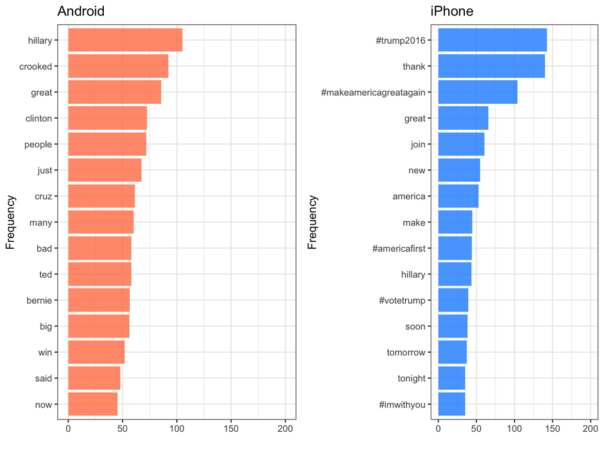

```r
# Using our ungrouped tfidf
tweet_dfm_tfidf_freq = textstat_frequency(tweet_dfm_tfidf, groups = source, force=TRUE)
View(tweet_dfm_tfidf_freq)

# Create dfs with top 15 features
android15_tfidf = tweet_dfm_tfidf_freq %>%
    filter(group == "Android") %>%
    arrange(desc(frequency)) %>%
    head(15)
iphone15_tfidf = tweet_dfm_tfidf_freq %>%
    filter(group == "iPhone") %>%
    arrange(desc(frequency)) %>%
    head(15)

# Plot and arrange side by side
android15_tfidf_plot = ggplot(data = android15_tfidf , aes(x = reorder(feature, frequency), y = frequency)) +
    geom_col(stat = "identity", alpha = 0.8, fill = "coral",
             position = position_dodge(width = 0.8)) +
    scale_y_continuous(limits = c(0, 200)) +
    xlab("Frequency") + ylab("") +
    ggtitle("Android") +
    coord_flip() +
    theme_bw()

iphone15_tfidf_plot = ggplot(data = iphone15_tfidf, aes(x = reorder(feature, frequency), y = frequency)) +
    geom_col(stat = "identity", alpha = 0.8, fill = "dodgerblue",
             position = position_dodge(width = 0.8)) +
    scale_y_continuous(limits = c(0, 200)) +
    xlab("Frequency") + ylab("") +
    ggtitle("iPhone") +
    coord_flip() +
    theme_bw()

ggpubr::ggarrange(android15_tfidf_plot, iphone15_tfidf_plot)
```

What do we observe? Now the output closely resembles the basic word frequency output; the order of some terms has changed, but top features across Android and iPhone overall are nearly identical. This happens because the TF-IDF scores are calculating rareness based on the whole corpus of tweets. In other words, the “TF-IDF then group” approach does not weigh *differences* between groups as heavily.

Like most TAD approaches, there is often not a right or wrong way to use word frequency approaches to make inferences. What’s more right or more wrong depends on the research question, hypothesis, and overarching research design. Generally, we need to consider the unit of analysis – specifically, what unit should be considered the “document” – before using weighting approaches. It’s worth noting that more groups in the grouping variable provides more variation in the TF-IDF calculation, reducing the number of zeros.

So, were Trump’s Android tweets more or less negative than Trump’s iPhone tweets? If it were our research project, we’d probably use both word frequency, TF-IDF, and manual content analysis in descriptive inference. We’d also probably apply sentiment analysis instead of word frequency approaches, which we’ll turn to next.

**Question 4 (BREAKOUT). Now take a TF-IDF approach to the “immigration_news_1995-2017.csv” dfm you created and list the top 15 TF-IDF terms. What similarities or differences do you see between this list and the word frequency approach? Which approach do you think is more helpful, and why?**

**Question 5 (BREAKOUT). Consider the pre-processing steps we took. Are there alternative pre-processing steps that might improve the analysis? Discuss.**